# Airbnb Exploratory Analysis

## Overview

The problem domain we are analyzing is publicly available information about different cities’ Airbnb listings data. Currently, our repo uses three Airbnb listing datasets: Boston, Chicago, and Singapore. Each dataset includes a diverse array of information about individual listings, with features such as host response rate, review score, accommodations, locations, etc. Because each city’s dataset contains the same features (and therefore mostly the same information), we may not end up analyzing all three dataset equally in this exploratory analysis.

## Summary Information

It is important for Airbnb users to have some information when they are looking for a place to stay. Therefore, we gathered some important pieces of information that people can utilize as they choose which city to stay in. The first piece of information we looked at was the number of listings in each city. Chicago has the most listings on Airbnb with $6397. Next we looked into the median price of a listing in each city to get a better understanding of the prices. Surprisingly, Boston was the most expensive city with a median price of $239.00.

To get a further sense of where Airbnbs are located within each city we broke the cities down by neighborhood From there, we were able to look at prices by neighborhood as well as the number of property types offered in each neighborhood. We also wanted to determine which city had the best superhost ratio so that people could determine where they are most likely to have a great host during their visit. We saw that Chicago had the best ratio of superhosts with 0.46 which was in stark contrast to Singapore with only 0.14 of their hosts being superhosts. These were just some of the things we found would be useful to someone deciding where to book their next Airbnb.

## Airbnb in Boston analysis based on features (Table section)

```r
kable(lowest_neighourhood, caption = 'lowest_neighourhoodl')
```

lowest_neighourhoodl

| toupper(neighbourhood) | lowest |
| --- | --- |
|  | $0.00 |
| 88AUCKLANDSTREET,APT1,DORCHESTER,MA0212,MASSACHUSETTS,UNITEDSTATES | $75.00 |
| Æ³¢Å£«É¡¿,MASSACHUSETTS,UNITEDSTATES | $100.00 |
| ALLSTON,MASSACHUSETTS,UNITEDSTATES | $42.00 |
| BOSTON(JAMAICAPLAIN),MASSACHUSETTS,UNITEDSTATES | $94.00 |
| BOSTON,,MASSACHUSETTS,UNITEDSTATES | $3,999.00 |
| BOSTON,ALLSTON,MA,UNITEDSTATES | $120.00 |
| BOSTON,MASSACHUSETTS,UNITEDSTATES | $1,000.00 |
| BOSTON/CHARLESTOWN,MASSACHUSETTS,UNITEDSTATES | $150.00 |
| BRIGHTON,MASSACHUSETTS,UNITEDSTATES | $34.00 |
| BROOKLINE,MASSACHUSETTS,UNITEDSTATES | $107.00 |
| CAMBRIDGE,MASSACHUSETTS,UNITEDSTATES | $112.57 |
| CHARLESTOWN,MASSACHUSETTS,UNITEDSTATES | $125.00 |
| CHESTNUTHILL,MASSACHUSETTS,UNITEDSTATES | $500.00 |
| DORCHESTER,,MASSACHUSETTS,UNITEDSTATES | $75.00 |
| DORCHESTER,MASSACHUSETTS,UNITEDSTATES | $120.00 |
| DORCHSTER,MASSACHUSETTS,UNITEDSTATES | $40.00 |
| EASTBOSTON,MASSACHUSETTS,UNITEDSTATES | $110.00 |
| HYDEPARK,MASSACHUSETTS,UNITEDSTATES | $80.00 |
| JAMAICAPLAIN,BOSTON,MASSACHUSETTS,UNITEDSTATES | $139.00 |
| JAMAICAPLAIN,MASSACHUSETTS,UNITEDSTATES | $107.00 |
| MILTON,MASSACHUSETTS,UNITEDSTATES | $117.00 |
| NEWTON,MASSACHUSETTS,UNITEDSTATES | $75.00 |
| ROSLINDALE,BOSTON,MASSACHUSETTS,UNITEDSTATES | $215.00 |
| ROSLINDALE,MASSACHUSETTS,UNITEDSTATES | $25.00 |
| ROXBURYCROSSING,MASSACHUSETTS,UNITEDSTATES | $154.00 |

- By aggregating each neighbourhood’s lowest price, user could have a picture of the price range in selected neigbourhood thus make better choice.

### Top 10 Neighborhoods in Singapore by Listing

This chart was intended to show the most common neighborhoods for Airbnb listings in Singapore by frequency:

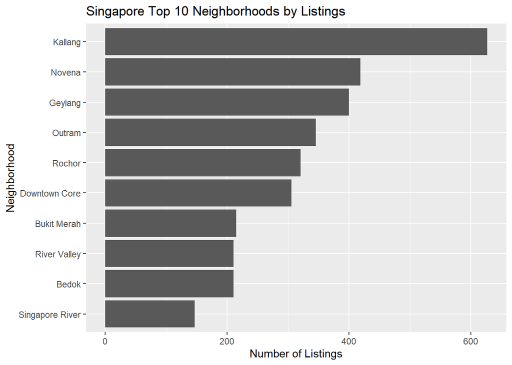

The above chart reveals that the top neighborhood by a large margin, is Kallang. Interestingly, the top 10 neighborhoods for Airbnb listings (as shown here) hardly match up with the top 10 most populous neighborhoods in Singapore. This could be an indication that the neighborhoods where many local Singaporeans actually live tend to be distinct from the neighborhoods that tourists (Such as Airbnb customers) stay in.

### Room Types of Listings on Airbnb in Boston

This pie chart is intended to show room types of all Airbnb listings in Boston:

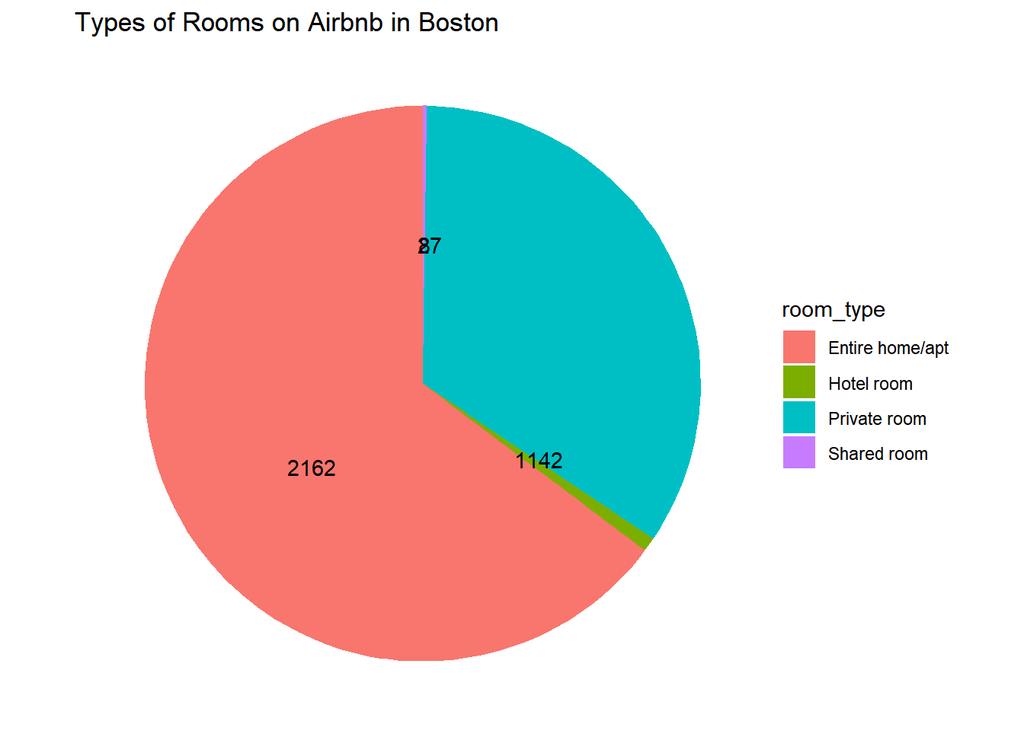

It reveals that over half of the listings are for entire home or apartment, while most of the rest are private rooms. There are little amounts of hotel rooms and shared rooms available. This can be helpful for people to decide how they want to display their listings(whether to rent out the entire home or separate rooms) and let them know how competitive their category is.

### Average Prices in Each City Based on Accommodation

This chart is intended to show the difference between the average price rates based on the number of accommodations needed in three different cities, Boston, Chicago, and Singapore for Airbnbs.

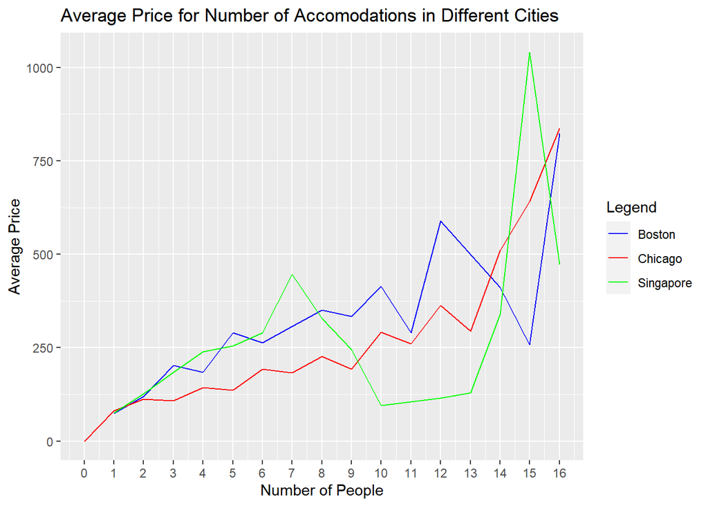